# lab1

Dawid Dąbkowski

2 października 2017

# Loading the data

```r
www <- "https://www.mimuw.edu.pl/~noble/courses/SDA/data/stockexchange.dat"
stockexchange <- read.table(www, header=T)
```

# Exercise 1: Simulating observations from a discrete distribution

```r
throw <- sample(1:6, 600, replace=T)
table(throw)
```

```
## throw
##   1   2   3   4   5   6
##  94  93 126  93  93 101
```

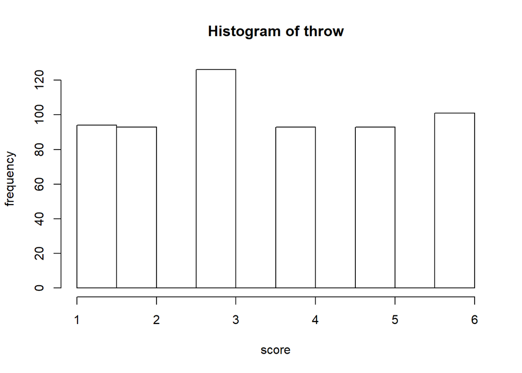

```r
hist(throw, xlab="score", ylab="frequency")
```

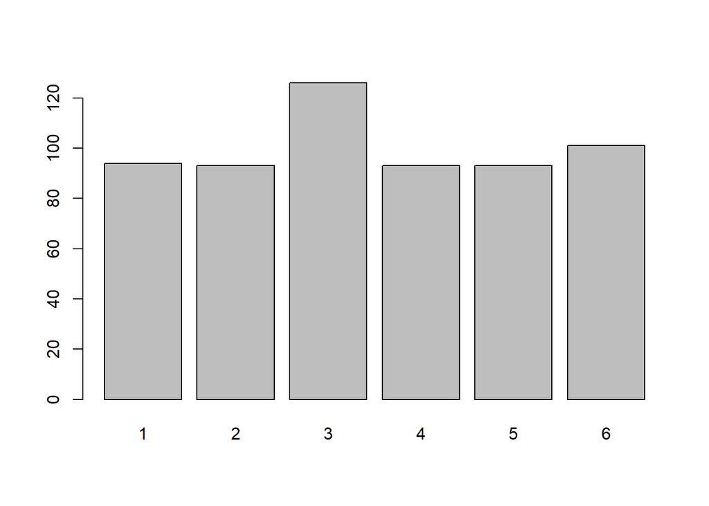

```r
barplot(table(throw))
```

```r
mean(throw)
```

```
## [1] 3.501667
```

```r
sd(throw)
```

```
## [1] 1.680686
```

# Exercise 2: Parameter estimation for a uniform distribution

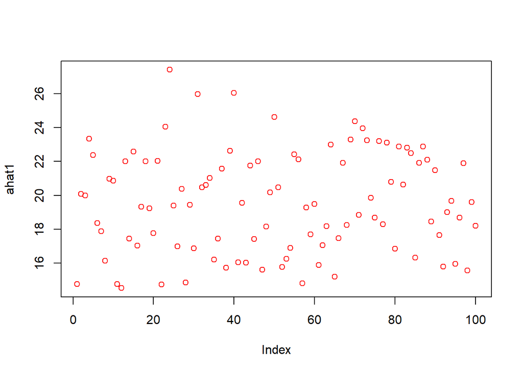

```r
rec <- runif(100, min=0, max=20)
rec <- matrix(runif(2000, min=0, max=20), 100, 20)
ahat1 <- 2*apply(rec, 1, mean)
ahat2 <- (21/20)*apply(rec, 1, max)
plot(ahat1, col="red")
```

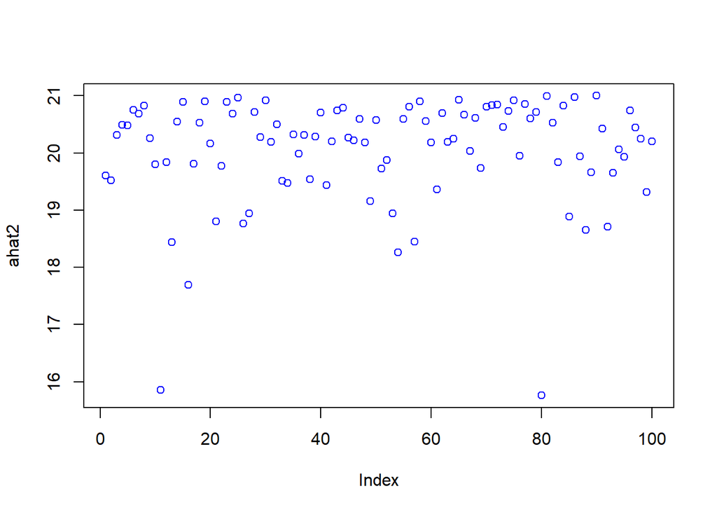

```r
plot(ahat2, col="blue", axes=T)
```

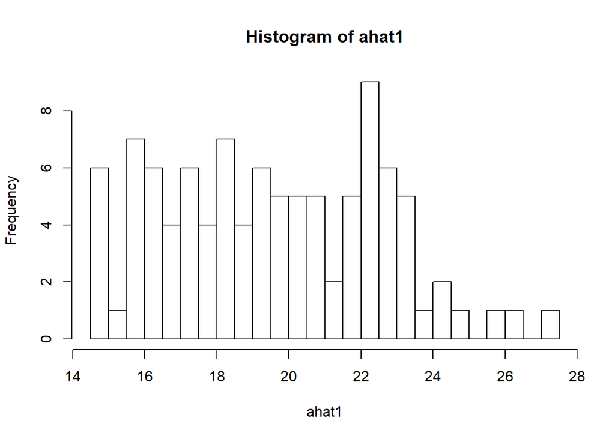

```r
hist(ahat1, breaks=20)
```

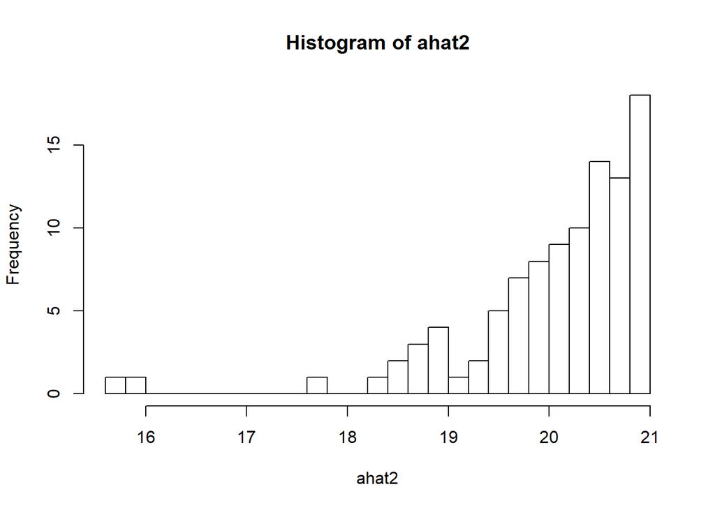

```r
hist(ahat2, breaks=20)
```

Note that the density function of the $\hat{a}_2$ is $g_2(x) = \frac{n}{20^n}x^{n-1}1_{[0,20]}(x)$

The theoretical and estimated means of $\hat{a}_1$ and $\hat{a}_2$ are:

$E(\hat{a}_1) = E(2\bar{X}) = \frac{2}{n}\sum_{j}E(x_j) = \frac{2\cdot n\cdot 10}{2} = 20$

```r
mean(ahat1)
```

```
## [1] 19.57251
```

$E(\hat{a}_2) = E(\frac{n+1}{n}max_{j}x_j) = \frac{n+1}{n}\int_{0}^{20}x\cdot\frac{n}{20^n}x^{n-1}\,dt = \frac{n+1}{20^n}\int_{0}^{20}x^n\,dt = \frac{n+1}{20^n} \cdot \frac{20^{n+1}}{n+1} = 20$

```r
mean(ahat2)
```

```
## [1] 20.05376
```

The theoretical and estimated standard deviations are:

$sd(\hat{a}_1) = \sqrt{Var(2\bar{x})} = \sqrt{\frac{4}{n^2}\sum_{j}Var(x_j)} = \sqrt{\frac{4}{n^2}\cdot n \cdot \frac{20^2}{12}} = \sqrt{\frac{20^2}{3n}} = \frac{20}{\sqrt{60}}$

```r
20/sqrt(60)
```

```
## [1] 2.581989
```

```r
sd(ahat1)
```

```
## [1] 2.986868
```

$sd(\hat{a}_2) = \sqrt{Var(\frac{n+1}{n}max_{j}x_j)} = \sqrt{E([...]^2)-E^2([...])} = \sqrt{(\frac{n+1}{n})^2(\int_{0}^{20}x^2\cdot \frac{n}{20^n}\cdot x^{n-1}\,dx) - 20^2} =$

$\sqrt{(\frac{n+1}{n})^2\cdot\frac{n}{20^n}\frac{20^{n+2}}{n+2} - 20^2} = \sqrt{\frac{(n+1)^2}{n(n+2)}\cdot 20^2 - 20^2} = 20 \sqrt{\frac{(n+1)^2}{n(n+2)} - 1} = 20 \sqrt{\frac{1}{440}}$

```r
20*sqrt(1/440)
```

```
## [1] 0.9534626
```

```r
sd(ahat2)
```

```
## [1] 0.9393154
```

# Exercise 3: Comparison of Volatilities

```r
library(car)
```

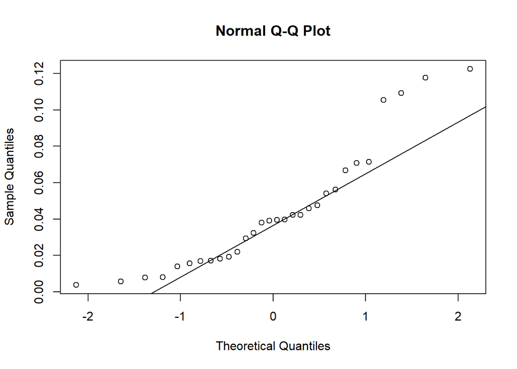

```r
stock2 <- abs(stockexchange)
qqnorm(stock2[,1])
qqline(stock2[,1])
```

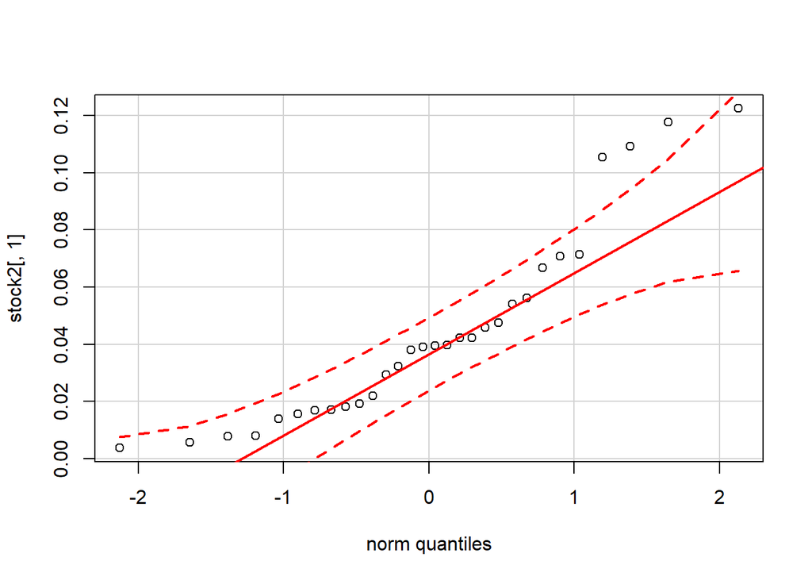

```r
qqPlot(stock2[,1])
```

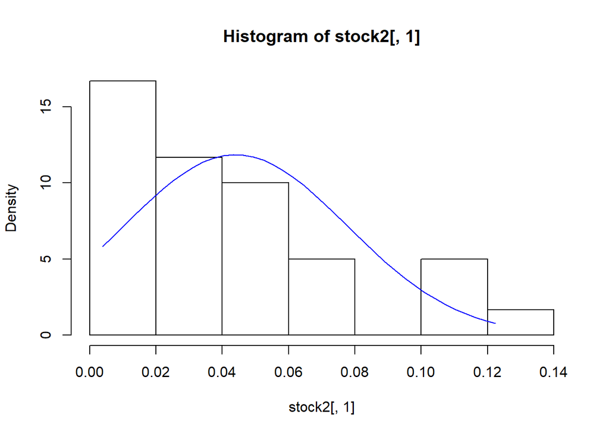

```r
m = mean(stock2[,1])
s = sd(stock2[,1])
hist(stock2[,1], probability=T)
pt <- seq(min(stock2[,1]), max(stock2[,1]), length=40)
lines(pt, dnorm(pt, mean=m, sd=s), col="blue")
```

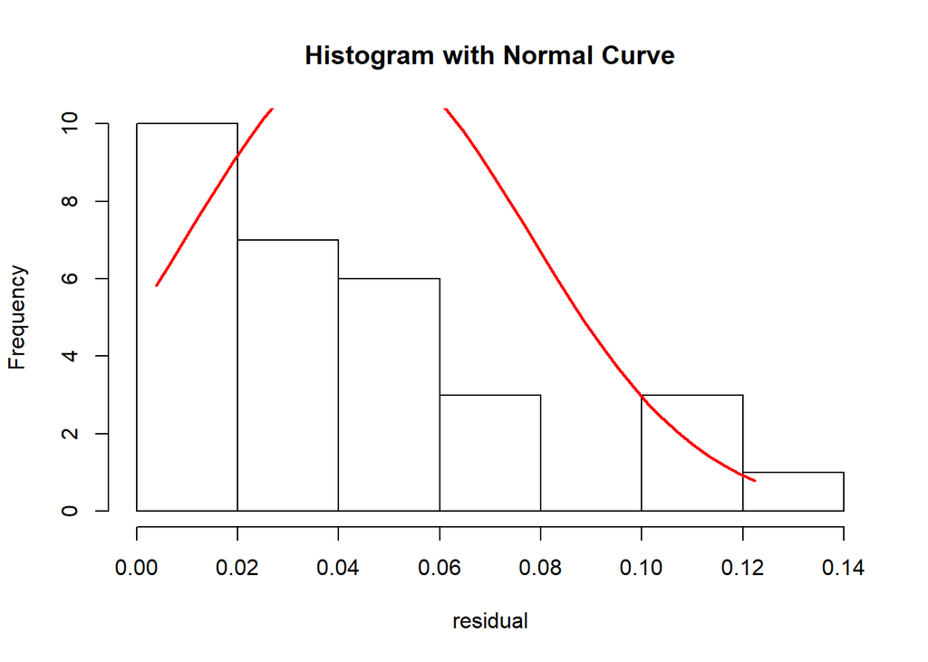

```r
z <- stock2[,1]
h <- hist(z, xlab="residual", main="Histogram with Normal Curve")
xfit <- seq(min(z), max(z), length=40)
yfit <- dnorm(xfit, mean=mean(z), sd=sd(z))
lines(xfit, yfit, col="red", lwd=2)
```

```r
stocktrans <- log(stock2 + 0.01)
s <- apply(stocktrans, 2, sd)
s
```

```
##      NASD      NYSE
## 0.6295807 0.5429186
```

```r
m <- apply(stocktrans, 2, mean)
m
```

```
##      NASD      NYSE
## -3.105020 -3.384848
```

```r
t.test(stocktrans[,1], stocktrans[,2], var.equal=T, paired=F)
```

```
##
##  Two Sample t-test
##
## data:  stocktrans[, 1] and stocktrans[, 2]
## t = 1.8436, df = 58, p-value = 0.07035
## alternative hypothesis: true difference in means is not equal to 0
## 95 percent confidence interval:
##  -0.02399645  0.58365258
## sample estimates:
## mean of x mean of y
## -3.105020 -3.384848
```

```r
t.test(stocktrans[,1], stocktrans[,2], alternative="greater", paired=F, var.equal=T, conf.level=0.95)
```

```
##
##  Two Sample t-test
##
## data:  stocktrans[, 1] and stocktrans[, 2]
## t = 1.8436, df = 58, p-value = 0.03517
## alternative hypothesis: true difference in means is greater than 0
## 95 percent confidence interval:
##  0.02611659        Inf
## sample estimates:
## mean of x mean of y
## -3.105020 -3.384848
```

# Exercise 4: Confidence intervals for differences in expected values when variances are different

```r
x <- rnorm(10, 22, 6)
y <- rnorm(31, 16, 2)
t.test(x, y, alternative="two.sided", paired=F, var.equal=F, conf.level=0.95)
```

```
##
##  Welch Two Sample t-test
##
## data:  x and y
## t = 2.5683, df = 9.69, p-value = 0.02863
## alternative hypothesis: true difference in means is not equal to 0
## 95 percent confidence interval:
##  0.5224307 7.5990084
## sample estimates:
## mean of x mean of y
##  19.52073  15.46001
```

```r
var.test(x, y, ratio=1, alternative="two.sided", conf.level=0.95)
```

```
##
##  F test to compare two variances
##
## data:  x and y
## F = 8.5227, num df = 9, denom df = 30, p-value = 6.788e-06
## alternative hypothesis: true ratio of variances is not equal to 1
## 95 percent confidence interval:
##   3.310302 30.344442
## sample estimates:
## ratio of variances
##           8.522738
```

From the low p-values we conclude that the means and variances are significantly different.

```r
qf(c(0.025, 0.975), 9, 30)
```

```
## [1] 0.2808665 2.5746101
```

```r
t.test(x, y, alternative="two.sided", paired=F, var.equal=T, conf.level=0.95)
```

```
##
##  Two Sample t-test
##
## data:  x and y
## t = 4.0154, df = 39, p-value = 0.0002616
## alternative hypothesis: true difference in means is not equal to 0
## 95 percent confidence interval:
##  2.015180 6.106259
## sample estimates:
## mean of x mean of y
##  19.52073  15.46001
```

With the wrong assumption we have much more degrees of freedom and higher t-statistic giving us lower p-value. So we are more likely to take the alternative hypothesis.

# Exercise 5: Confidence level when using normal approximation

```r
n <- 16
p <- 0.3
bindat <- rbinom(1000, n, p)
phat <- bindat/n
lower <- phat - 1.96*sqrt(phat*(1-phat)/n)
upper <- phat + 1.96*sqrt(phat*(1-phat)/n)
l <- sum(lower>p)
u <- sum(upper<p)
miss <- l+u
miss
```

```
## [1] 144
```

We have missed much more than theoretical 50.

```r
n <- 80
p <- 0.3
bindat <- rbinom(1000, n, p)
phat <- bindat/n
lower <- phat - 1.96*sqrt(phat*(1-phat)/n)
upper <- phat + 1.96*sqrt(phat*(1-phat)/n)
l <- sum(lower>p)
u <- sum(upper<p)
miss <- l+u
miss
```

```
## [1] 67
```

With more observations we are closer to the theoretical 50.

# Exercise 6: Power of the t-test

```r
n <- 16
N <- 1000
X <- matrix(rnorm(n*N, 5, 1.2), N, n)
me <- apply(X, 1, mean)
s <- apply(X, 1, sd)
u <- (me-5)/(s/sqrt(n))
tval <- qt(0.975, n-1)
reject0 <- sum(u>tval)+sum(u<(-1)*tval)
reject0
```

```
## [1] 49
```

```r
X <- matrix(rnorm(n*N, 6, 1.2), N, n)
me <- apply(X, 1, mean)
s <- apply(X, 1, sd)
u <- (me-5)/(s/sqrt(n))
reject1 <- sum(u>tval)+sum(u<(-1)*tval)
reject1
```

```
## [1] 887
```

```r
binom.test(reject1, 1000, conf.level=0.95)
```

```
##
##  Exact binomial test
##
## data:  reject1 and 1000
## number of successes = 887, number of trials = 1000, p-value <
## 2.2e-16
## alternative hypothesis: true probability of success is not equal to 0.5
## 95 percent confidence interval:
##  0.8657282 0.9059603
## sample estimates:
## probability of success
##                  0.887
```

```r
power.t.test(n=16, delta=1, sd=1.2, sig.level=0.05, type="one.sample", alternative="two.sided", strict=T)
```

```
##
##      One-sample t test power calculation
##
##               n = 16
##           delta = 1
##              sd = 1.2
##       sig.level = 0.05
##           power = 0.8756852
##     alternative = two.sided
```